# Nadeem Bishtawi Assignment 1

## Importing All Packages

```python
#Importing all necessary packages for databse loading,manipulation and graphing.
import numpy as np
import pandas as pd
import seaborn as sns
import matplotlib.pyplot as plt
sns.set(color_codes=True) #set seaborn background color.
```

## Loading Database

```python
pd.set_option('display.max_columns', None) #ensure all coulmns are on display.
data = pd.read_csv("CardioGoodFitness.csv") #load the database.
```

## Viewing first rows of the Dataset

```python
data.head(10) #view the first 10 rows of data.
```

|  | Product | Age | Gender | Education | MaritalStatus | Usage | Fitness | Income | Miles |
| --- | --- | --- | --- | --- | --- | --- | --- | --- | --- |
| 0 | TM195 | 18 | Male | 14 | Single | 3 | 4 | 29562 | 112 |
| 1 | TM195 | 19 | Male | 15 | Single | 2 | 3 | 31836 | 75 |
| 2 | TM195 | 19 | Female | 14 | Partnered | 4 | 3 | 30699 | 66 |
| 3 | TM195 | 19 | Male | 12 | Single | 3 | 3 | 32973 | 85 |
| 4 | TM195 | 20 | Male | 13 | Partnered | 4 | 2 | 35247 | 47 |
| 5 | TM195 | 20 | Female | 14 | Partnered | 3 | 3 | 32973 | 66 |
| 6 | TM195 | 21 | Female | 14 | Partnered | 3 | 3 | 35247 | 75 |
| 7 | TM195 | 21 | Male | 13 | Single | 3 | 3 | 32973 | 85 |
| 8 | TM195 | 21 | Male | 15 | Single | 5 | 4 | 35247 | 141 |
| 9 | TM195 | 21 | Female | 15 | Partnered | 2 | 3 | 37521 | 85 |

Observation:

1. Data looks clean and matches that of the assignment context.

## Checking data types to ensure the data is read correctly

```python
data.dtypes #checking data types.
```

```
Product          object
Age               int64
Gender           object
Education         int64
MaritalStatus    object
Usage             int64
Fitness           int64
Income            int64
Miles             int64
dtype: object
```

Observations:

1. Product, Gender and MaritalStatus are object data type.
2. All other variables are numerical and their data types conform top that.
3. Gender and MaritalStatus are currently object, should be categorical.

```python
data.Gender = data.Gender.astype('category') #fixing the data types for Gender and marital status.
data.MaritalStatus = data.MaritalStatus.astype('category')
```

```python
data.dtypes #checking data types after change.
```

```
Product            object
Age                 int64
Gender           category
Education           int64
MaritalStatus    category
Usage               int64
Fitness             int64
Income              int64
Miles               int64
dtype: object
```

## Ensuring there are no empty cells in the data

```python
data.isnull().sum()
#check for empty cells, every empty cell returns a 1 and summed up to show how many empty cells are ina  column.
```

```
Product          0
Age              0
Gender           0
Education        0
MaritalStatus    0
Usage            0
Fitness          0
Income           0
Miles            0
dtype: int64
```

Observations:

1. No non-zero sum, that means all columns are filled.

## Checking the Shape of the Data

```python
data.shape
```

```
(180, 9)
```

Observations:

1. 9 columns, 180 rows.

## Looking at the Quantitative Variables

```python
data.describe() #returns analysis of data means, std, quartiles, max and mins
```

|  | Age | Education | Usage | Fitness | Income | Miles |
| --- | --- | --- | --- | --- | --- | --- |
| count | 180.000000 | 180.000000 | 180.000000 | 180.000000 | 180.000000 | 180.000000 |
| mean | 28.788889 | 15.572222 | 3.455556 | 3.311111 | 53719.577778 | 103.194444 |
| std | 6.943498 | 1.617055 | 1.084797 | 0.958869 | 16506.684226 | 51.863605 |
| min | 18.000000 | 12.000000 | 2.000000 | 1.000000 | 29562.000000 | 21.000000 |
| 25% | 24.000000 | 14.000000 | 3.000000 | 3.000000 | 44058.750000 | 66.000000 |
| 50% | 26.000000 | 16.000000 | 3.000000 | 3.000000 | 50596.500000 | 94.000000 |
| 75% | 33.000000 | 16.000000 | 4.000000 | 4.000000 | 58668.000000 | 114.750000 |
| max | 50.000000 | 21.000000 | 7.000000 | 5.000000 | 104581.000000 | 360.000000 |

Observations:

1. Very Wide spread of miles expected ranging from 21 miles to 360 miles.
2. Age and Income means above the 50% range, also larger difference between 50% and 75% than 25% to 50%.
3. The 25% and 50% values are the same for Usage and Fitness is the same. Their means are similar to those values.
4. The 50% and 75% values of Education are very close, its mean is close to those values.

## Univariate Analyses

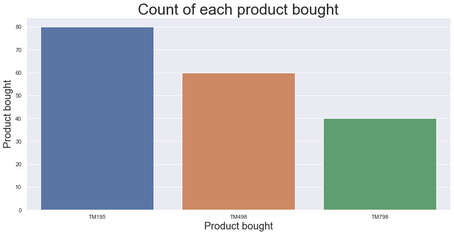

```python
plt.figure(figsize=(15, 7)) #change figure size
sns.countplot(x="Product", data=data) #create a count plot using the product column.
plt.title("Count of each product bought", fontsize = 30) #titles the graph.
plt.ylabel('Product bought', fontsize = 20) #changes y axis label.
plt.xlabel('Product bought', fontsize = 20) #changes x axis label.
plt.show() #show the graph.
```

Observation:

1. The TM195 is the most sold product followed by the TM498 and the TM798.

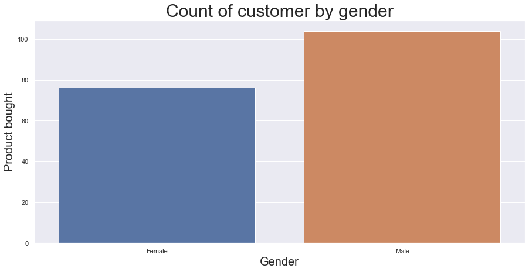

```python
plt.figure(figsize=(15, 7)) #change figure size
sns.countplot(x="Gender", data= data) #create a countplot using the gender column.
plt.title("Count of customer by gender", fontsize = 30) #titles the graph.
plt.ylabel('Product bought', fontsize = 20) #changes y axis label.
plt.xlabel('Gender', fontsize = 20) #changes x axis label.
plt.show() #show the graph.
```

Observations:

1. Product bought more by male customers than female customers.

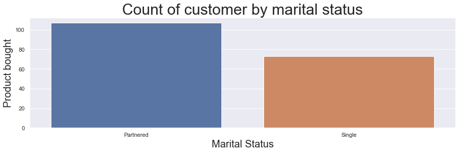

```python
plt.figure(figsize=(15,4)) #change figure size
sns.countplot(x="MaritalStatus", data= data)  #create a countplot using the Marital status column.
plt.title("Count of customer by marital status", fontsize = 30) #titles the graph.
plt.ylabel('Product bought', fontsize = 20) #changes y axis label.
plt.xlabel('Marital Status', fontsize = 20) #changes x axis label.
plt.show() #show the graph.
```

Observations:

1. Product bought more by partnered customers than single customers.

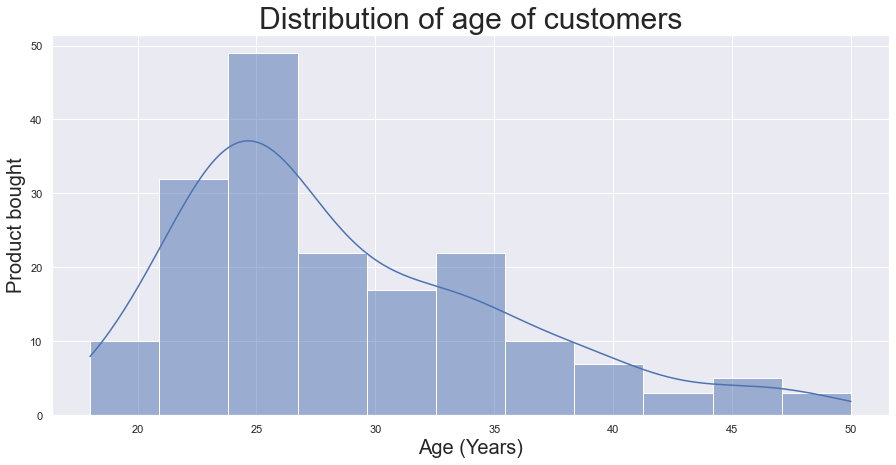

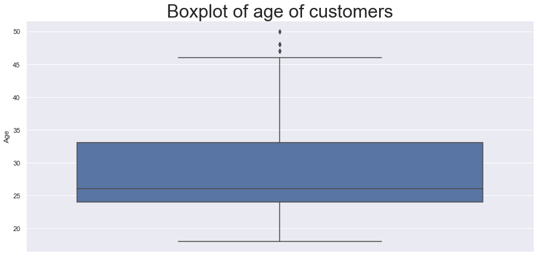

```python
plt.figure(figsize=(15, 7)) #change figure size
sns.histplot(data.Age,kde=True ); #creates a histogram of the age of product, showing the KDE curve.
plt.title("Distribution of age of customers", fontsize = 30)  #titles the graph.
plt.ylabel('Product bought', fontsize = 20) #changes y axis label.
plt.xlabel('Age (Years)', fontsize = 20) #changes x axis label.
plt.show() #show the histogram graph.
plt.figure(figsize=(15, 7)) #change figure size
sns.boxplot(y='Age', data = data); #creates a boxplot.
plt.title("Boxplot of age of customers", fontsize = 30) #titles the graph.
plt.show() #show the boxplot graph.
```

Observations:

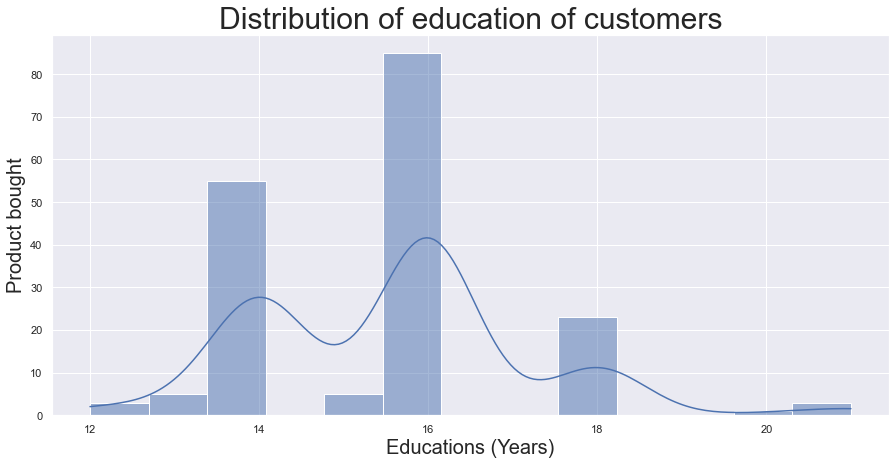

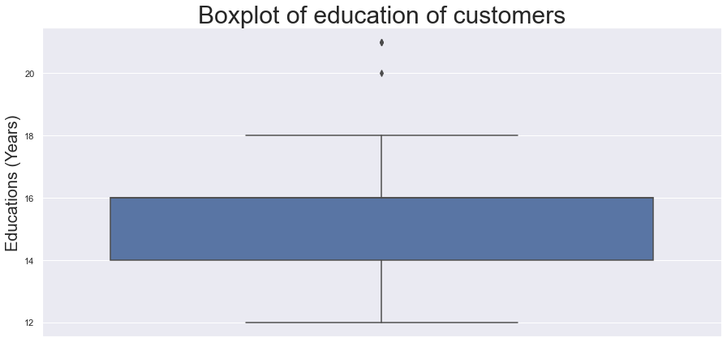

```python
plt.figure(figsize=(15, 7)) #change figure size
sns.histplot(data.Education,kde=True ); #creates a histogram of the education column, showing the KDE curve.
plt.title("Distribution of education of customers", fontsize = 30) #titles the graph.
plt.ylabel('Product bought', fontsize = 20) #changes y axis label.
plt.xlabel("Educations (Years)", fontsize = 20) #changes x axis label.
plt.show() #show the histogram graph.
plt.figure(figsize=(15, 7)) #change figure size
sns.boxplot(y='Education', data = data); #creates a boxplot of the education column.
plt.title("Boxplot of education of customers", fontsize = 30) #titles the graph.
plt.ylabel("Educations (Years)", fontsize = 20) #changes y axis label.
plt.show() #show the boxplot graph.
```

Observations:

1. Distribution shows slight left skew most products bought by people with educations of 16 years.
2. Mean is not noticble on boxplot because it is so close to the 75% mark.
3. Outliers are above 18 years of education.
4. impossibly small/nonexistant median to Q3 range , larger Q2 to median range.

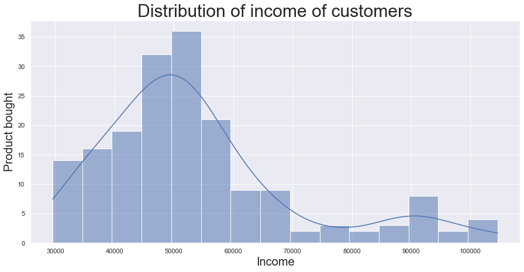

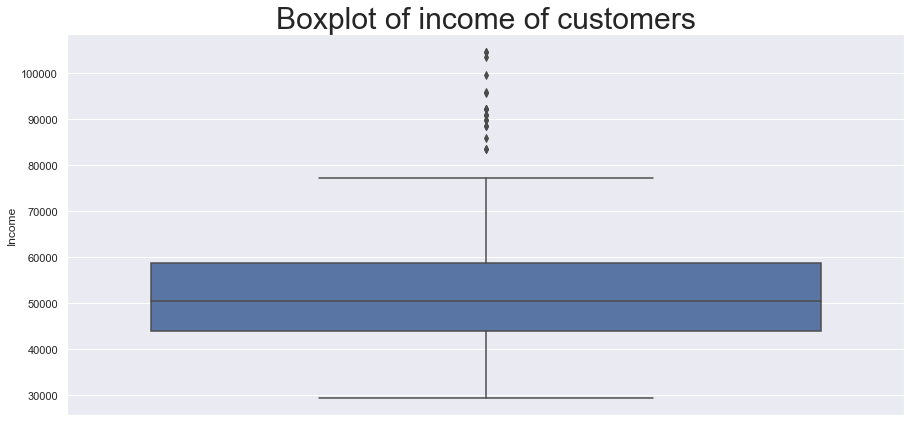

```python
plt.figure(figsize=(15, 7)) #change figure size
sns.histplot(data.Income,kde=True ); #creates a histogram of the income column, showing the KDE curve.
plt.title("Distribution of income of customers", fontsize = 30) #titles the graph.
plt.ylabel('Product bought', fontsize = 20) #changes y axis label.
plt.xlabel('Income', fontsize = 20) #changes x axis label.
plt.show() #show the histogram graph.
plt.figure(figsize=(15, 7)) #change figure size
sns.boxplot(y='Income', data = data); #creates a boxplot of the income column.
plt.title("Boxplot of income of customers", fontsize = 30) #titles the graph.
plt.show() #show the boxplot graph.
```

Observations:

1. Histogram shows right skewness with the most products bought by people with approximately 54,000-55,000 dollars of income.
2. Outliers are above 79,000 dollars on boxplot.
3. Mean around 54,000 dollars, mean seems to be evenly between Q2 and Q3.

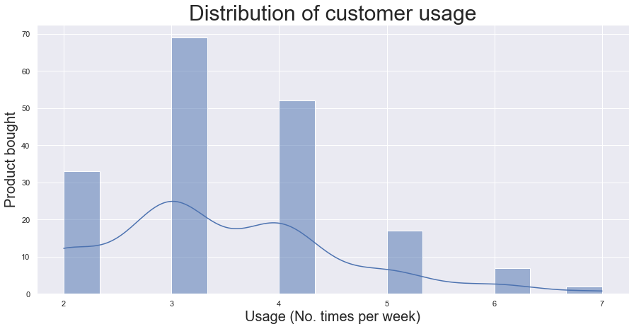

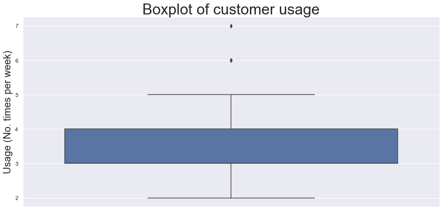

```python
plt.figure(figsize=(15, 7)) #change figure size
sns.histplot(data.Usage,kde=True ); #creates a histogram of the usage column, showing the KDE curve.
plt.title("Distribution of customer usage", fontsize = 30) #titles the graph.
plt.ylabel('Product bought', fontsize = 20) #changes y axis label.
plt.xlabel('Usage (No. times per week)', fontsize = 20) #changes x axis label.
plt.show() #show the histogram graph.
plt.figure(figsize=(15, 7)) #change figure size
sns.boxplot(y='Usage', data = data); #creates a boxplot of the usage column.
plt.title("Boxplot of customer usage", fontsize = 30) #titles the graph.
plt.ylabel('Usage (No. times per week)', fontsize = 20) #changes y axis label.
plt.show() #show the boxplot graph.
```

Observations:

1. Histogram shows right skewness with the most products bought by people using it 3 times a week.
2. Outliers are above 5 usages on boxplot.
3. Mean isnt visible on boxplot as it is the same as the Q2 value.
4. Small/nonexistant Q2 to median, larger median to Q3 on boxplot.

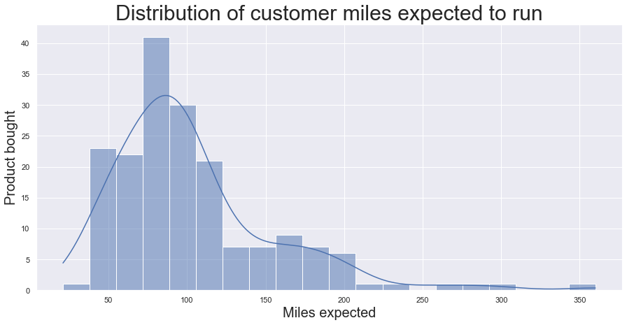

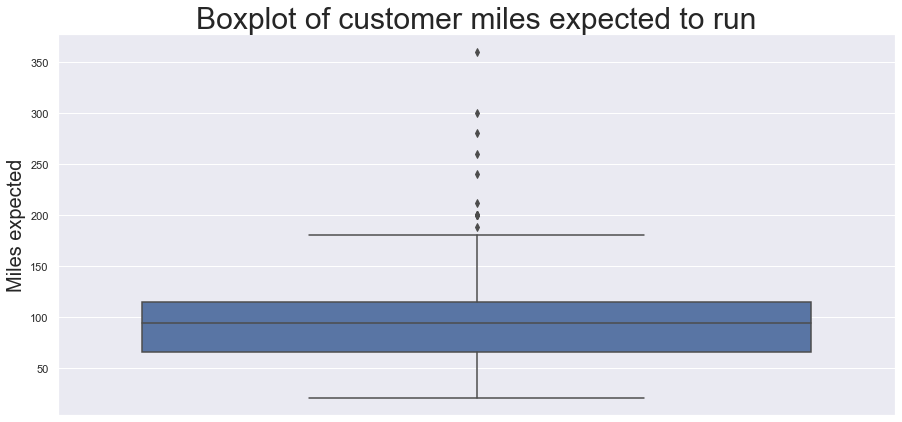

```python
plt.figure(figsize=(15, 7)) #change figure size
sns.histplot(data.Miles,kde=True ); #creates a histogram of the miles column, showing the KDE curve.
plt.title("Distribution of customer miles expected to run", fontsize = 30) #titles the graph.
plt.ylabel('Product bought', fontsize = 20) #changes y axis label.
plt.xlabel('Miles expected', fontsize = 20) #changes x axis label.
plt.show() #show the histogram graph.
plt.figure(figsize=(15, 7)) #change figure sizes
sns.boxplot(y='Miles', data = data); #creates a boxplot of the miles column.
plt.ylabel('Miles expected', fontsize = 20) #changes y axis label.
plt.title("Boxplot of customer miles expected to run", fontsize = 30) #titles the graph.
plt.show() #show the boxplot graph.
```

Observations:

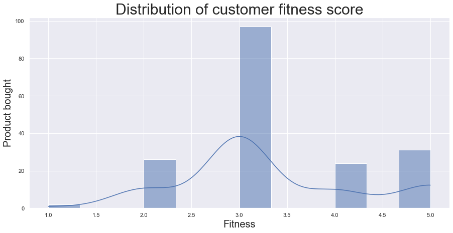

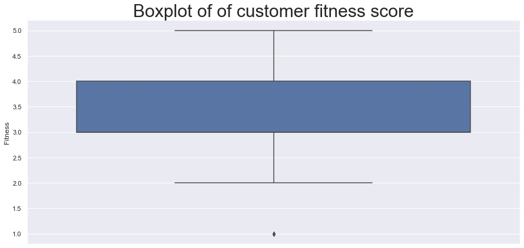

```python
plt.figure(figsize=(15, 7)) #change figure size
sns.histplot(data.Fitness,kde=True ); #creates a histogram of the fitness column, showing the KDE curve.
plt.title("Distribution of customer fitness score", fontsize = 30) #titles the graph.
plt.ylabel('Product bought', fontsize = 20) #changes y axis label.
plt.xlabel('Fitness', fontsize = 20) #changes x axis label.
plt.show() #show the histogram graph.
plt.figure(figsize=(15, 7)) #change figure size
sns.boxplot(y='Fitness', data = data); #creates a boxplot of the fitness column.
plt.title("Boxplot of of customer fitness score", fontsize = 30) #titles the graph.
plt.show() #show the boxplot graph.
```

Observations:

1. Histogram shows a slight right skew with the most products bought by people who rated a 3 fitness score.
2. Outliers are below 2 fitness score on boxplot.
3. Mean isnt visible on boxplot as it is the same as the Q2 value.
4. Small/nonexistant Q2 to median, large median to Q3 on boxplot.

## Multivariate Analyses

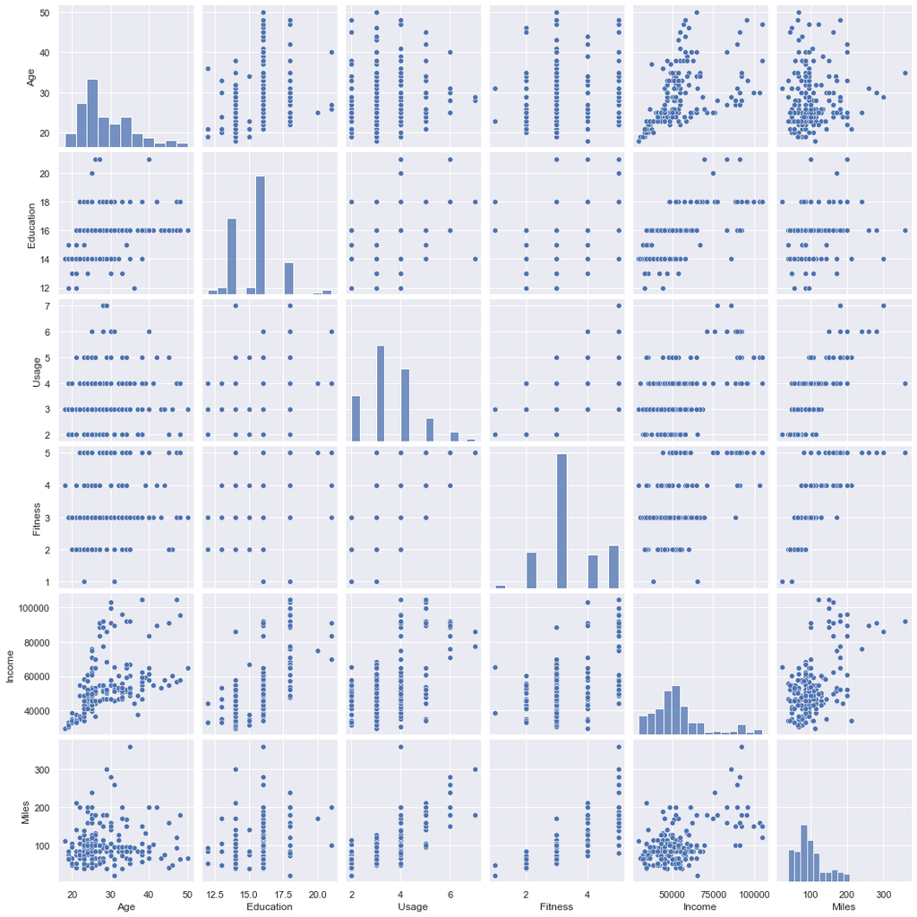

```python
sns.pairplot(data) #plot pairwise relationships in the data.
plt.show() #show the pairplot.
```

```python
correlation = data.corr() #create correlation table for all numeric variables.
correlation
```

|  | Age | Education | Usage | Fitness | Income | Miles |
| --- | --- | --- | --- | --- | --- | --- |
| Age | 1.000000 | 0.280496 | 0.015064 | 0.061105 | 0.513414 | 0.036618 |
| Education | 0.280496 | 1.000000 | 0.395155 | 0.410581 | 0.625827 | 0.307284 |
| Usage | 0.015064 | 0.395155 | 1.000000 | 0.668606 | 0.519537 | 0.759130 |
| Fitness | 0.061105 | 0.410581 | 0.668606 | 1.000000 | 0.535005 | 0.785702 |
| Income | 0.513414 | 0.625827 | 0.519537 | 0.535005 | 1.000000 | 0.543473 |
| Miles | 0.036618 | 0.307284 | 0.759130 | 0.785702 | 0.543473 | 1.000000 |

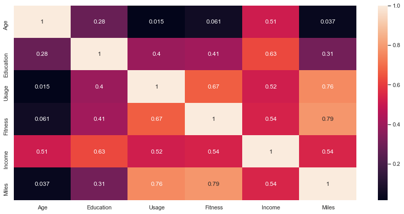

```python
plt.figure(figsize=(15, 7)) #change figure size
sns.heatmap(correlation, annot=True) # visual colored map of correlation table.
plt.show() #shows graph
```

Observations:

1. Fitness has a high positive correlation with miles, and a mild positive correlation with usage.
2. Miles has a high positive correlation usage.
3. Income has a mild positive correlation with Education.
4. Age has low positive correlations with other variables, its highest correlation is a mild positive correlation with income.

## Product Quantitative Multivariate Analysis

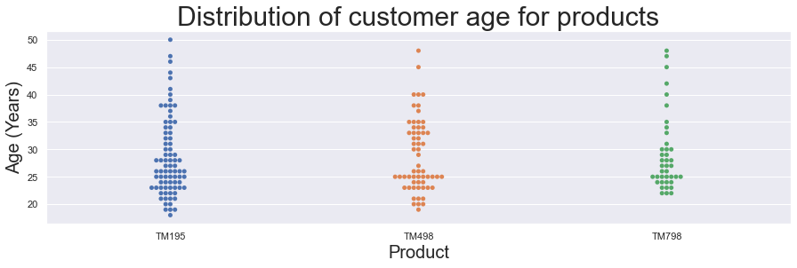

```python
plt.figure(figsize=(15, 4)) #change figure size
sns.swarmplot(x='Product', y = 'Age', data = data) #creates swarm graph for the age of customers and their distributions across products.
plt.title("Distribution of customer age for products", fontsize = 30) #titles the graph.
plt.ylabel('Age (Years)', fontsize = 20) #changes y axis label.
plt.xlabel('Product', fontsize = 20) #changes x axis label.
plt.show() #shows graph.
```

Observations:

1. Age shows a similar trend across the board between all 3 products.

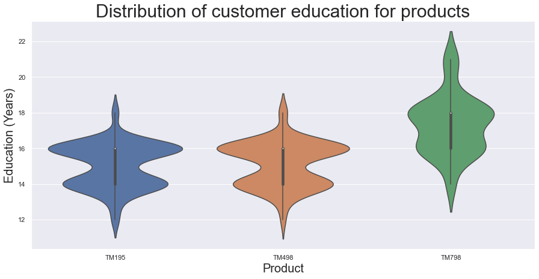

```python
plt.figure(figsize=(15, 7)) #change figure size
sns.violinplot(x='Product', y = 'Education', data = data) #creates violin plot for the education in years of customers across products.
plt.title("Distribution of customer education for products", fontsize = 30) #titles the graph.
plt.ylabel('Education (Years)', fontsize = 20) #changes y axis label.
plt.xlabel('Product', fontsize = 20) #changes x axis label.
plt.show() #show graph.
```

Observations:

1. The products TM498 and TM195 have similar means of around 16 years and distribution among the same education levels.
2. The TM798 product shows an increased distribution at higher education levels and a higher mean of 18 years of education among customers.

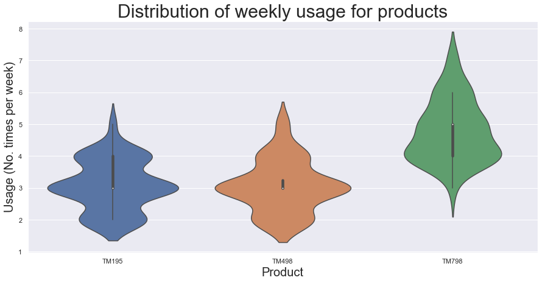

```python
plt.figure(figsize=(15, 7)) #change figure size
sns.violinplot(x='Product', y = 'Usage', data = data) #creates violin plot for the weekly usage of customers across products.
plt.title("Distribution of weekly usage for products", fontsize = 30) #titles the graph.
plt.ylabel('Usage (No. times per week)', fontsize = 20) #changes y axis label.
plt.xlabel('Product', fontsize = 20) #changes x axis label.
plt.show() #shows graph.
```

Observations:

1. The products TM498 and TM195 have violin shapes and similar means of approx 3 uses a week.
2. TM498 has small interquartile range (a smaller distribution) while Tm195 has a larger interquartile range ( a larger distribution).
3. The TM798 product shows an increased distribution and a higher mean of 5 uses per week.

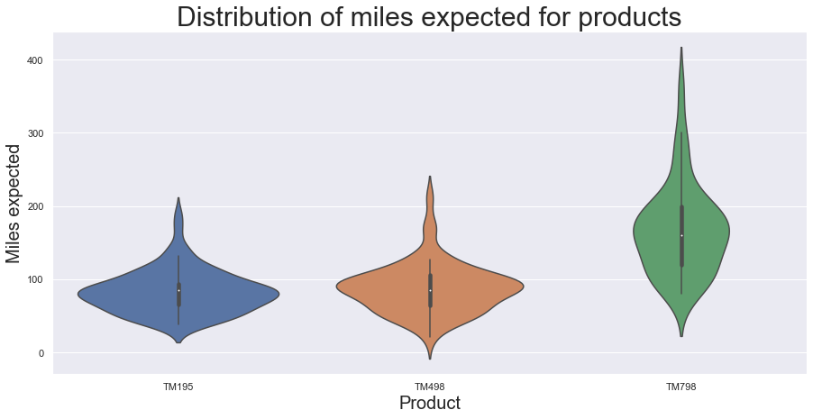

```python
plt.figure(figsize=(15, 7)) #change figure size
sns.violinplot(x='Product', y = 'Miles', data = data) #creates violin plot for the expected miles customers will run across products.
plt.title("Distribution of miles expected for products", fontsize = 30) #titles the graph.
plt.ylabel('Miles expected', fontsize = 20) #changes y axis label.
plt.xlabel('Product', fontsize = 20) #changes x axis label.
plt.show() #shows graph.
```

Observations:

1. Shape is wide around the TM195 and TM498 products indicating spread of values around the mean.
2. Mean of TM195 and TM498 is similar at around 90 miles expected.
3. Mean of TM798 is higher, approx 160. Shape indicates a concentration of values around the mean.
4. Data indicates when the customer expects to run more miles they buy a TM798.

## Splitting Data for deeper analysis

```python
Male = data['Gender'] == 'Male'
maledata= data[Male]
Female = data['Gender'] == 'Female'
femaledata= data[Female]
single = data['MaritalStatus'] == 'Single'
singledata= data[single]
partnered = data['MaritalStatus'] == 'Partnered'
partnereddata= data[partnered]
```

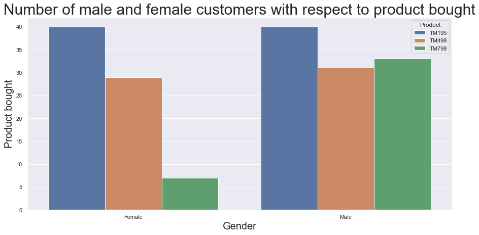

```python
plt.figure(figsize=(15, 7)) #change figure size
sns.countplot(x="Gender", hue= 'Product', data= data) #creates count plot for the number of male and female customers that bought the different products.
plt.title("Number of male and female customers with respect to product bought", fontsize = 30) #titles the graph.
plt.ylabel('Product bought', fontsize = 20) #changes y axis label.
plt.xlabel('Gender', fontsize = 20) #changes x axis label.
plt.show() #shows graph.
```

Observations:

1. Among males and females the trend is that they buy TM195 the most.
2. For males this is followed by Tm798 and then closely followed by TM498.
3. For Females the next product bought most is TM498 then at a much lower product amount TM798.

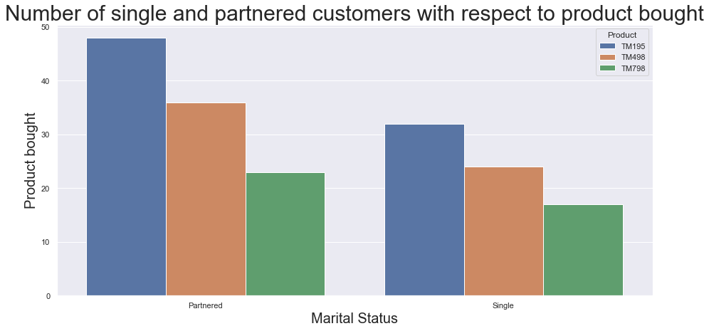

```python
plt.figure(figsize=(15, 7)) #change figure size
sns.countplot(x="MaritalStatus", hue= 'Product', data= data) #creates count plot for the number of that bought the different products from each marital status.
plt.title("Number of single and partnered customers with respect to product bought", fontsize = 30) #titles the graph.
plt.ylabel('Product bought', fontsize = 20) #changes y axis label.
plt.xlabel('Marital Status', fontsize = 20) #changes x axis label.
plt.show() #shows graph.
```

Observations:

1. Both partnered and single customers follow the same trend, buying TM1945 at the highest amounts, followed by TM498 and finally TM798.

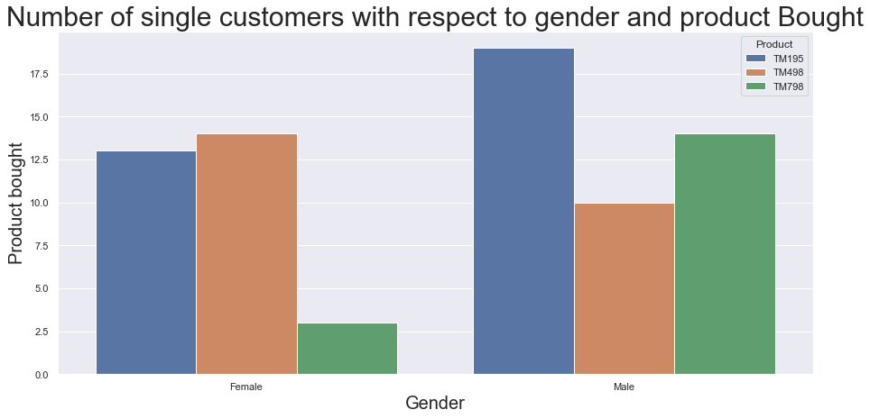

```python
plt.figure(figsize=(15, 7)) #change figure size
sns.countplot(x='Gender',hue = 'Product', data= singledata) #creates count plot for the number of single male and female customers that bought the different products.
plt.title("Number of single customers with respect to gender and product bought", fontsize = 30) #titles the graph.
plt.ylabel('Product bought', fontsize = 20) #changes y axis label.
plt.xlabel('Gender', fontsize = 20) #changes x axis label.
plt.show() #shows graph.
```

Observations:

1. Among single males: most by the TM195, followed by the TM798 and the TM498.
2. Among single females: most by the TM498, followed closely by the TM498 and then much lower is the TM798.

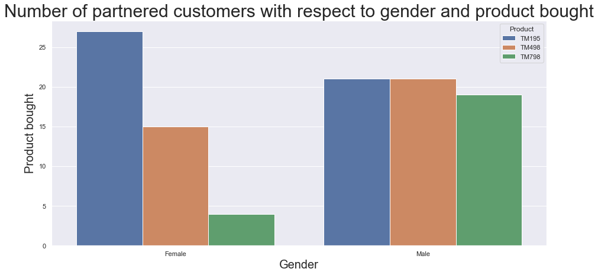

```python
plt.figure(figsize=(15, 7)) #change figure size
sns.countplot(x='Gender',hue = 'Product', data= partnereddata) #creates count plot for the number partnered of male and female customers that bought the different products.
plt.title("Number of partnered customers with respect to gender and product bought", fontsize = 30) #titles the graph.
plt.ylabel('Product bought', fontsize = 20) #changes y axis label.
plt.xlabel('Gender', fontsize = 20) #changes x axis label.
plt.show() #shows graph.
```

Observations:

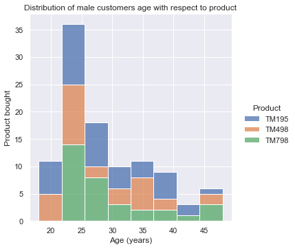

```python
#plt.figure(figsize=(15, 7)) Does not work, cannot figure out how to fix
sns.displot(maledata, x='Age', hue = 'Product', multiple = 'stack') #creates count plot for the number of male customers that bought the different products.
plt.title("Distribution of male customers age with respect to product") #titles the graph.
plt.ylabel('Product bought') #changes y axis label.
plt.xlabel('Age (years)') #changes x axis label.
plt.show() #shows graph.
```

Observations:

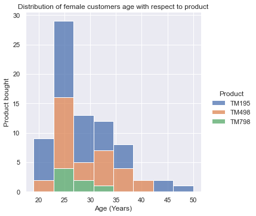

```python
#plt.figure(figsize=(15, 7)) Does not work, cannot figure out how to fix
sns.displot(x='Age', data = femaledata, hue = 'Product', multiple = 'stack') #creates count plot for the number of female customers that bought the different products.
plt.title("Distribution of female customers age with respect to product") #titles the graph.
plt.ylabel('Product bought') #changes y axis label.
plt.xlabel('Age (Years)') #changes x axis label.
plt.show() #shows graph.
```

Observations:

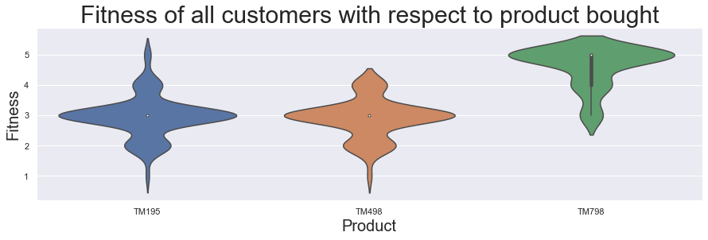

```python
plt.figure(figsize=(15, 4)) #change figure size
sns.violinplot(x='Product', y = 'Fitness', data = data) #creates violin plot for the distribution of customer fitness that bought the different products.
plt.title("Fitness of all customers with respect to product bought", fontsize = 30) #titles the graph.
plt.ylabel('Fitness', fontsize = 20) #changes y axis label.
plt.xlabel('Product', fontsize = 20) #changes x axis label.
plt.show() #shows graph.
```

Observations:

1. Shapes of violin plot suggest that a large distribution of customers who rate themselves higher than 4 on fitness tend to to buy TM798.
2. TM195 and TM498 follow similar distribution patterns at a similar means of customer rated 3 fitness.
3. People at a higher rated fitness did not buy a TM498.

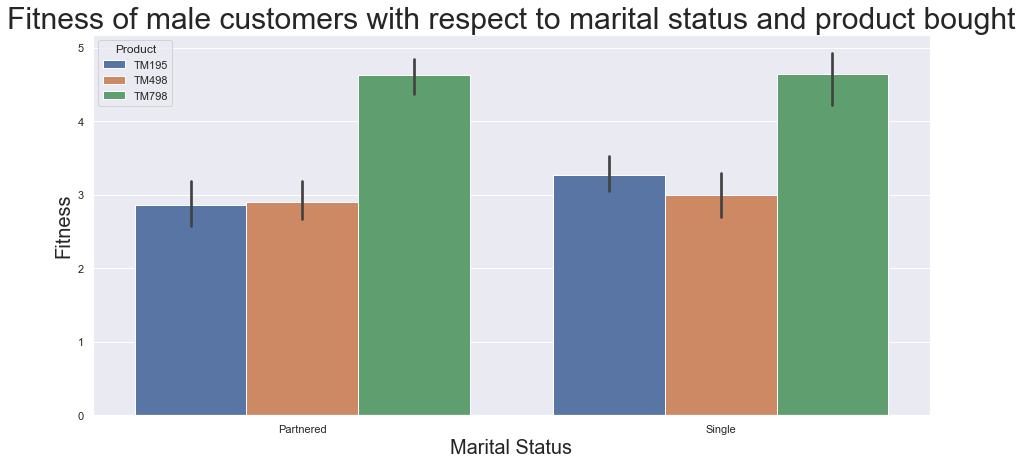

```python
plt.figure(figsize=(15, 7)) #change figure size
sns.barplot(x= 'MaritalStatus', y= 'Fitness', hue ='Product', data = maledata) #creates bar chart for the number of male customers that bought the different products filtered by marital status.
plt.title("Fitness of male customers with respect to marital status and product bought", fontsize = 30) #titles the graph.
plt.ylabel('Fitness', fontsize = 20) #changes y axis label.
plt.xlabel('Marital Status', fontsize = 20) #changes x axis label.
plt.show() #shows graph.
```

Observations:

1. At higher fitness among both partnered and single males, they buy the TM798 most.
2. Among single males at lower fitness ratings this is followed by TM195 and then closely by TM498.
3. Among partnered males at lower fitness ratings, this is followed by TM498 then very closely by TM195.

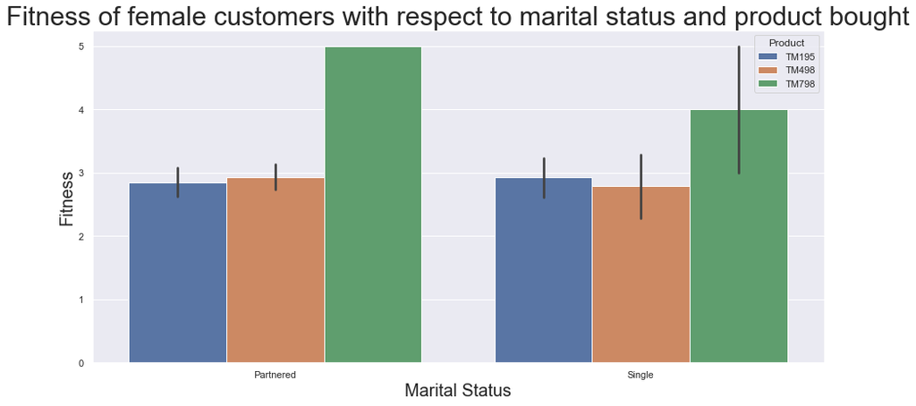

```python
plt.figure(figsize=(15, 7)) #change figure size
sns.barplot(x= 'MaritalStatus', y= 'Fitness', hue ='Product', data = femaledata) #creates bar chart for the number of female customers that bought the different products filtered by marital status.
plt.title("Fitness of female customers with respect to marital status and product bought", fontsize = 30) #titles the graph.
plt.xlabel('Marital Status', fontsize = 20) #changes x axis label.
plt.ylabel('Fitness', fontsize = 20) #changes y axis label.
plt.show() #shows graph.
```

Observations:

1. At higher fitness among both partnered and single females, they buy the TM798 most.
2. Among single females at lower fitness ratings this is followed by TM195 and then closely by TM498.
3. Among partnered males at lower fitness ratings, this is followed by TM498 then very closely by TM195.

## Conclusions

TM195:

TM498:

TM798:

- At higher fitness ratings among both partnered and single males and females the TM798 is preferred.
- Males younger than 22 and females younger than 23 and older than 35 do not buy the TM798.
- Among all 3 products the TM798 is the least bought.
- Among single males the TM798 is the second most bought product.
- At higher frequency of use and expected mile usage the TM798 is bought more frequently.